# A Footnote in History

R

tables

The grammar of tables, footnotes and occupations consigned to history

Author

Carl Goodwin

Published

November 1, 2022

Modified

June 30, 2024

[figure not shown]

The nature of employment has seen significant shifts over time. Occupations are being consigned to ‘footnotes in history’ whilst others grow driven by trends such as concern for the environment.

Producing a journal-quality table requires fine-grained and reproducible control over presentation. Surgical targeting of footnotes, capable of adapting to changes in the underlying data, is one example.

This post briefly explores the shifts in the nature of employment whilst at the same time more fully exploring the grammar of tables [gt](https://gt.rstudio.com)(Iannone et al. 2022): The natural companion to the grammar of graphics [ggplot2](https://ggplot2.tidyverse.org)(Wickham 2016).

```r
library(conflicted)
library(tidyverse)
conflict_prefer_all("dplyr", quiet = TRUE)
library(readxl)
library(gt)
library(ggfoundry)
library(usedthese)

conflict_scout()
```

In [Digging Deep](https://www.quantumjitter.com/project/planning/), the [DT package](https://rstudio.github.io/DT/) is used to produce a *reactable* table; one with sortable and searchable columns. DT is intended as an R interface to the DataTables library, but reactivity is not yet supported in gt.

Data frames are liberally printed across all projects including, for example, a table to summarise an auto-generated overview of R packages and functions used in each project. The YAML option `df-print: kable` renders a nice table (with striped rows) in these cases.

For this project something a little more sophisticated is needed.

As a guiding principle, [Posit](https://posit.co) packages are my first port of call. This provides a confidence in cross-package consistency, interoperability, longevity and an investment in development and support. Hence gt is the go-to package for the footnoted table further down.

As the intent is to present a summary in the style of the Financial Times, we’ll need a suitable custom [colour palette](https://registry.origami.ft.com/components/o-colors@6.4.2).

```r
theme_set(theme_bw())

pal <- c(
  "#FFF1E5", "#F2DFCE",
  "#333333", "#800D33",
  "#C00000", "#00994D"
)

pal_name <- "Financial Times"

display_palette(pal, pal_name)
```

[figure not shown]

The labour market data are sourced from the [Office for National Statistics](https://www.nomisweb.co.uk/datasets/aps168/reports/employment-by-occupation?compare=K02000001)[^1].

```r
read_data <- \(x) {
  read_xlsx(
    x,
    skip = 12,
    col_names = c(
      "occupation",
      "persons"
    ),
    col_types = c(
      "text",
      "numeric",
      "skip",
      "skip",
      "skip",
      "skip",
      "skip"
    )
  )
} |>
  mutate(year = x |> str_remove(".xlsx") |> as.integer())

pop_df <- list("2004.xlsx", "2021.xlsx") |>
  map(read_data) |>
  list_rbind()
```

There’s a hierarchy to the data, so I’ll extract the lowest level and then slice off the top and bottom occupations based on their percentage change over time.

```r
change_df <- pop_df |>
  filter(str_starts(occupation, "\\d{4} ")) |>
  pivot_wider(names_from = year, values_from = persons) |>
  separate_wider_regex(occupation,
                       c(soc = "\\d{4}", " ", occupation = ".*")) |>
  mutate(change = `2021` / `2004` - 1) |>
  arrange(desc(change)) |>
  mutate(group = if_else(row_number() <= 10, "Risers", "Fallers")) |>
  slice(c(1:10, (n()-10):n())) |>
  relocate(group)
```

The handling of footnotes is a particularly nice feature in [gt](https://gt.rstudio.com): The package automatically assigns, and maintains the order of, the superscripted numbers (could also be symbols) to ensure they flow naturally. And targeting offers a high degree of control and reproducibility.

For example, two entries (highlighted light blue) in the table below use the abbreviation *n.e.c.*. The footnote may be targeted at rows which *contain that string* rather than having to manually identify the rows. And once added, any subsequent footnotes would be renumbered to maintain the flow. So, if I were to change the source datasets to different years or countries, all references to *n.e.c.* would be auto-magically found and appropriately footnoted.

```r
gt_tbl <- change_df |>
  gt(rowname_col = c("occupation"), groupname_col = "group") |>
  tab_header(title = "UK Employment by Occupation") |>
  tab_options(table.width = pct(100)) |>
  fmt_number(
    columns = starts_with("2"),
    decimals = 0
  ) |>
  fmt_percent(
    columns = starts_with("c"),
    decimals = 0,
    force_sign = TRUE
  ) |>
  sub_missing() |>
  tab_spanner(
    label = "Year",
    columns = starts_with("2")
  ) |>
  tab_style(
    style = cell_text(transform = "capitalize"),
    locations = cells_column_labels(!starts_with("s"))
  ) |>
  tab_style(
    style = cell_text(transform = "uppercase"),
    locations = cells_column_labels("soc")
  ) |>
  tab_footnote(
    footnote = "Not elsewhere classified",
    locations = cells_stub(rows = contains("n.e.c."))
  ) |>
  tab_footnote(
    footnote = "Count of all persons",
    locations = cells_column_spanners()
  ) |>
  tab_footnote(
    footnote = "Standard Occupational Classification 2020",
    locations = cells_column_labels(columns = "soc")
  ) |>
  tab_footnote(
    footnote = "Top & bottom 10 occupations ordered by percent change",
    locations = cells_row_groups(groups = c("Risers", "Fallers"))
  ) |>
  tab_footnote(
    footnote = "Figures suppressed as statistically unreliable",
    locations = cells_body(
      columns = c(change, `2021`),
      rows = is.na(change)
    )
  ) |>
  tab_source_note(source_note = "Source: Office for National Statistics (ONS)")

gt_tbl |>
  tab_style_body(
    style = cell_fill(color = "lightblue"),
    pattern = "n.e.c.",
    extents = "stub"
  ) |>
  opt_stylize(style = 6, color = "gray", add_row_striping = TRUE) |>
  as_raw_html()
```

UK Employment by Occupation

|  | soc<sup>2</sup> | Year<sup>1</sup> 2004 | Year<sup>1</sup> 2021 | change |  |
| --- | --- | --- | --- | --- | --- |
| Risers<sup>3</sup> |  |  |  |  |  |
| Industrial cleaning process occupations | 9132 | 26,300 | 241,100 |  | +817% |
| Health professionals n.e.c.<sup>4</sup> | 2219 | 9,000 | 70,100 | +679% |  |
| Police community support officers | 3315 | 2,100 | 13,900 | +562% |  |
| Business and financial project management professionals | 2424 | 58,300 | 350,000 | +500% |  |
| Advertising and public relations directors | 1134 | 19,400 | 69,000 | +256% |  |
| IT business analysts, architects and systems designers | 2135 | 82,800 | 270,500 | +227% |  |
| Aircraft maintenance and related trades | 5235 | 27,200 | 88,300 | +225% |  |
| Quality assurance and regulatory professionals | 2462 | 43,700 | 138,000 | +216% |  |
| Officers of non-governmental organisations | 4114 | 41,800 | 127,200 | +204% |  |
| Environment professionals | 2142 | 17,500 | 52,100 | +198% |  |
| Fallers<sup>3</sup> |  |  |  |  |  |
| Sheet metal workers | 5213 | 29,100 | 10,900 | −63% |  |
| Process operatives n.e.c.<sup>4</sup> | 8119 | 22,200 | 8,200 | −63% |  |
| Footwear and leather working trades | 5413 | 13,000 | 4,800 | −63% |  |
| Printing machine assistants | 8127 | 22,600 | 8,100 | −64% |  |
| Assemblers (electrical and electronic products) | 8131 | 63,200 | 20,700 | −67% |  |
| Printers | 5422 | 63,600 | 8,900 | −86% |  |
| Chartered architectural technologists | 2435 | 2,400 | <sup>5</sup> — | <sup>5</sup> — |  |
| Moulders, core makers and die casters | 5212 | 3,900 | <sup>5</sup> — | <sup>5</sup> — |  |
| Air-conditioning and refrigeration engineers | 5225 | 19,400 | <sup>5</sup> — | <sup>5</sup> — |  |
| Pre-press technicians | 5421 | 8,600 | <sup>5</sup> — | <sup>5</sup> — |  |
| Coal mine operatives | 8122 | 2,600 | <sup>5</sup> — | <sup>5</sup> — |  |

Source: Office for National Statistics (ONS)  
<sup>1</sup> Count of all persons  
<sup>2</sup> Standard Occupational Classification 2020  
<sup>3</sup> Top & bottom 10 occupations ordered by percent change  
<sup>4</sup> Not elsewhere classified  
<sup>5</sup> Figures suppressed as statistically unreliable

The above table uses one of the in-built style theme options. It looks clean and polished. But sometimes the table to be published needs a high degree of customisation to match, for example, a specific branding. [gt](https://gt.rstudio.com) offers this as we’ll demonstrate by attempting to replicate the style employed by the [market data in the Financial Times](https://markets.ft.com/data/).

UK Employment by Occupation

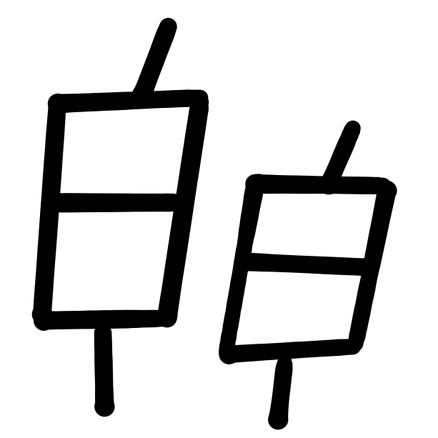

soc<sup>2</sup>

Year<sup>1</sup>

change

2004

2021

Risers<sup>3</sup>

Industrial cleaning process occupations

9132

26,300

241,100

+817%

Health professionals n.e.c.<sup>4</sup>

2219

9,000

70,100

+679%

Police community support officers

3315

2,100

13,900

+562%

Business and financial project management professionals

2424

58,300

350,000

+500%

Advertising and public relations directors

1134

19,400

69,000

+256%

IT business analysts, architects and systems designers

2135

82,800

270,500

+227%

Aircraft maintenance and related trades

5235

27,200

88,300

+225%

Quality assurance and regulatory professionals

2462

43,700

138,000

+216%

Officers of non-governmental organisations

4114

41,800

127,200

+204%

Environment professionals

2142

17,500

52,100

+198%

Fallers<sup>3</sup>

Sheet metal workers

5213

29,100

10,900

−63%

Process operatives n.e.c.<sup>4</sup>

8119

22,200

8,200

−63%

Footwear and leather working trades

5413

13,000

4,800

−63%

Printing machine assistants

8127

22,600

8,100

−64%

Assemblers (electrical and electronic products)

8131

63,200

20,700

−67%

Printers

5422

63,600

8,900

−86%

Chartered architectural technologists

2435

2,400

<sup>5</sup> —

<sup>5</sup> —

Moulders, core makers and die casters

5212

3,900

<sup>5</sup> —

<sup>5</sup> —

Air-conditioning and refrigeration engineers

5225

19,400

<sup>5</sup> —

<sup>5</sup> —

Pre-press technicians

5421

8,600

<sup>5</sup> —

<sup>5</sup> —

Coal mine operatives

8122

2,600

<sup>5</sup> —

<sup>5</sup> —

Source: Office for National Statistics (ONS)

<sup>1</sup> Count of all persons

<sup>2</sup> Standard Occupational Classification 2020

<sup>3</sup> Top & bottom 10 occupations ordered by percent change

<sup>4</sup> Not elsewhere classified

<sup>5</sup> Figures suppressed as statistically unreliable

```r
gt_ft <- gt_tbl |>
  tab_options(
    table.border.top.color = pal[1],
    table.border.bottom.color = pal[1],
    table.background.color = pal[1],
    table.font.size = px(10),
    table.font.color = pal[3],
    heading.align = "left",
    heading.title.font.size = px(20),
    heading.title.font.weight = "bold",
    heading.background.color = pal[1],
    row.striping.include_table_body = TRUE,
    row.striping.include_stub = TRUE,
    row.striping.background_color = pal[2],
    row_group.background.color = pal[1]
  ) |>
  tab_header(title = html("UK Employment by Occupation  ",
                          local_image("logo.png", height = 20))) |>
  tab_style(
    style = list(
      cell_text(font = "Financier Display"),
      cell_borders(sides = "bottom", weight = px(3), color = "#262A33")
      ),
    locations = cells_title()
  ) |>
  tab_style(
    style = cell_text(size = px(14)),
    locations = cells_row_groups()
  ) |>
  tab_style(
    style = cell_text(color = pal[4], weight = "bold"),
    locations = cells_stub()
  ) |>
  tab_style(
    style = cell_text(weight = "bold"),
    locations = list(cells_column_labels(),
                     cells_column_spanners(),
                     cells_row_groups())
  ) |>
  tab_style(
    style = cell_borders(style = "hidden"),
    locations = list(cells_body(),
                     cells_row_groups(),
                     cells_stub())
  ) |>
  tab_style(
    style = cell_text(color = pal[6], weight = "bold"),
    locations = cells_body(
      columns = change,
      rows = change >= 0
    )
  ) |>
  tab_style(
    style = cell_text(color = pal[5], weight = "bold"),
    locations = cells_body(
      columns = change,
      rows = change < 0
    )
  ) |>
  tab_style(
    style = cell_text(color = "grey40", size = px(9)),
    locations = list(cells_footnotes(), cells_source_notes())
  )

gt_ft |> as_raw_html()
```

## R Toolbox

Summarising below the packages and functions used in this post enables me to separately create a toolbox visualisation summarising the usage of packages and functions across all posts.

```r
used_here()
```

| Package | Function |
| --- | --- |
| base | as.integer[1], c[8], is.na[1], library[6], list[5] |
| conflicted | conflict_prefer_all[1], conflict_scout[1] |
| dplyr | arrange[1], desc[1], filter[1], if_else[1], mutate[3], n[2], relocate[1], row_number[1], slice[1] |
| ggfoundry | display_palette[1] |
| ggplot2 | theme_bw[1], theme_set[1] |
| gt | as_raw_html[2], cell_borders[2], cell_fill[1], cell_text[9], cells_body[4], cells_column_labels[4], cells_column_spanners[2], cells_footnotes[1], cells_row_groups[4], cells_source_notes[1], cells_stub… |
| purrr | list_rbind[1], map[1] |
| readxl | read_xlsx[1] |
| stringr | str_remove[1], str_starts[1] |
| tidyr | pivot_wider[1], separate_wider_regex[1] |
| tidyselect | contains[1], starts_with[4] |
| usedthese | used_here[1] |

## References

Iannone, Richard, Joe Cheng, Barret Schloerke, Ellis Hughes, and JooYoung Seo. 2022. *Gt: Easily Create Presentation-Ready Display Tables*.

Wickham, Hadley. 2016. *Ggplot2: Elegant Graphics for Data Analysis*. https://ggplot2.tidyverse.org.

## Footnotes

[^1]: Contains public sector information licensed under the [Open Government Licence v3.0](https://www.nationalarchives.gov.uk/doc/open-government-licence/version/3/).